# Lab 3: Topic Analysis

Erica Bishop

2023-04-28

```r
library(quanteda)
library(tm)
library(topicmodels)
library(ldatuning)
library(tidyverse)
library(tidytext)
library(reshape2)
library(slam)
library(LexisNexisTools)
library(LDAvis) #visualization
library("tsne") #matrix decomposition
```

### Assignment Lab 3:

Due in 2 weeks: May 2 at 11:59PM

For this assignment you’ll the articles data you downloaded from Nexis Uni in Week 2.

Changed search terms slightly to hopefully get rid of sports-related articles (Puget Sound AND Orcas AND NOT soccer)

## Step 1

1. Create a corpus from your articles.

```r
#reading in all of the documents in one file
all_files <- list.files(pattern = ".docx"
                       , path = "/Users/ericabishop/Documents/MEDSspring/EDS231/lab3_docs"
                       , full.names = TRUE
                       , recursive = TRUE
                       , ignore.case = TRUE)

#reading in LexisNexis file
LNT_dat <- lnt_read(all_files)

# Separate data types into different dfs
meta_df <- LNT_dat@meta
articles_df <- LNT_dat@articles #this is the one to create a corpus from
paragraphs_df <- LNT_dat@paragraphs

#clean out some article headers / city words / dates
articles_clean <- articles_df %>%
  mutate(Article = str_replace(Article, "Classification Language:.*", "")) %>%
  mutate(Article = str_replace(Article, "Contact:.*", "")) %>%
  mutate(Article = str_replace(Article, "Email:.*", "")) %>%
  mutate(Article = str_replace(Article, "COMMENTS.*", "")) %>%
  mutate_all(~str_remove(., "MIAMI (AP) — ") %>%
              str_remove(., "(TNStalk) -- ") %>%
              str_remove(., "SEATTLE") %>%
              str_remove(., "WASHINGTON, Dec. 16 -- ") %>%
              str_remove(., "By Associated Press ") %>%
              str_remove(., "WASHINGTON, Dec. 22 --" )  %>%
              str_remove(., "SEATTLE (AP)") %>%
              str_remove(., "(TNSPol) -- ") %>%
              str_remove(., "(TNSPol) -- ") %>%
              str_remove(., "Dec 20, 2022( Homeland Preparedness News: https://homelandprepnews.com Delivered by Newstex)   Shutterstock  ") %>%
              str_remove(., "Oct. 8—") %>%
              str_remove(., "Aug 05, 2022( Environmental Protection Agency News: https://www.epa.gov/newsroom Delivered by Newstex)   August 5, 2022   Contact Information   SEATTLE (August 5, 2022)—") %>%
              str_remove(., "By Michael Doyle This story was updated at 7:07 p.m. EST. ") %>%
              str_remove(., "Mar 14, 2023( Alaska Beacon: https://alaskabeacon.com/ Delivered by Newstex)") %>%
              str_remove(., "MIAMI - ") %>%
              str_remove(., "WASHINGTON, Dec. 8 -- ") %>%
              str_remove(., "Nov 23, 2022( Northwest Progressive Institute Advocate: http://www.nwprogressive.org/weblog/ Delivered by Newstex)") %>%
              str_remove(., "ABOARD THE SOUNDGUARDIAN, Puget Sound (AP) — ") %>%
              str_remove(., "TACOMA, Wash., Dec. 14 -- ") %>%
              str_remove(., "OLYMPIA - ") %>%
              str_remove(., "MOUNT VERNON - ") %>%
              str_remove(., "Aug 11, 2022( MarketBeat: https://www.marketbeat.com/ Delivered by Newstex)  ") %>%
              str_remove(., "Sep. 24")) %>%
    mutate(Article = str_trim(Article)) #remove whitespace


#saving as csv to read back in as spec_tbl_df
write_csv(articles_clean, here::here("articles_df.csv"))

#now its the right class for corpus to work
articles_tbl <- read_csv(here::here("articles_df.csv"))
```

```r
articles_tbl <- articles_tbl %>%
   rename(text = Article) #rename column header to match

corp_orcas <- corpus(x = articles_tbl, text_field = "text") # make the corpus

articles_stats <- summary(corp_orcas) # grab some stats
# articles_stats
```

## Step 2

2. Clean the data as appropriate.

```r
# extract words as tokens without punctuation or numbers
toks <- tokens(corp_orcas, remove_punct = TRUE, remove_numbers = TRUE)

 # add search terms as stop words
add_stops <- c(stopwords("en"), "puget", "sound", "orcas")

# remove stop words from token list
toks1 <- tokens_select(toks, pattern = add_stops, selection = "remove")
```

```r
dfm_orcas <- dfm(toks1, tolower = TRUE, remove_padding = TRUE)

#words must occur in at least two documents to be included in analysis
dfm <- dfm_trim(dfm_orcas, min_docfreq = 2)

# calculate sum of words then keep ones greater than zero
sel_idx <- slam::row_sums(dfm) > 0
dfm <- dfm[sel_idx,]
```

## Run models

3. Run three models (i.e. with 3 values of k) and select the overall best value for k (the number of topics) - include some justification for your selection: theory, FindTopicsNumber() optimization metrics, interpretability, LDAvis. Select the best single value of k.

```r
result <- FindTopicsNumber(dfm,
                            topics = seq(from = 2, to = 20, by = 1),
                            metrics = c("CaoJuan2009", "Deveaud2014", "Arun2010"),
                            method = "Gibbs",
                            verbose = T)
```

```
## fit models... done.
## calculate metrics:
##   CaoJuan2009... done.
##   Deveaud2014... done.
##   Arun2010... done.
```

```r
# plot(result)

head(result)
```

```
##   topics CaoJuan2009 Deveaud2014 Arun2010
## 1     20   0.1739326    1.476177 46.22187
## 2     19   0.1810478    1.487127 47.93833
## 3     18   0.1794731    1.513396 49.02051
## 4     17   0.1832245    1.536197 49.49545
## 5     16   0.1898314    1.541686 50.95426
## 6     15   0.1909478    1.551569 51.98035
```

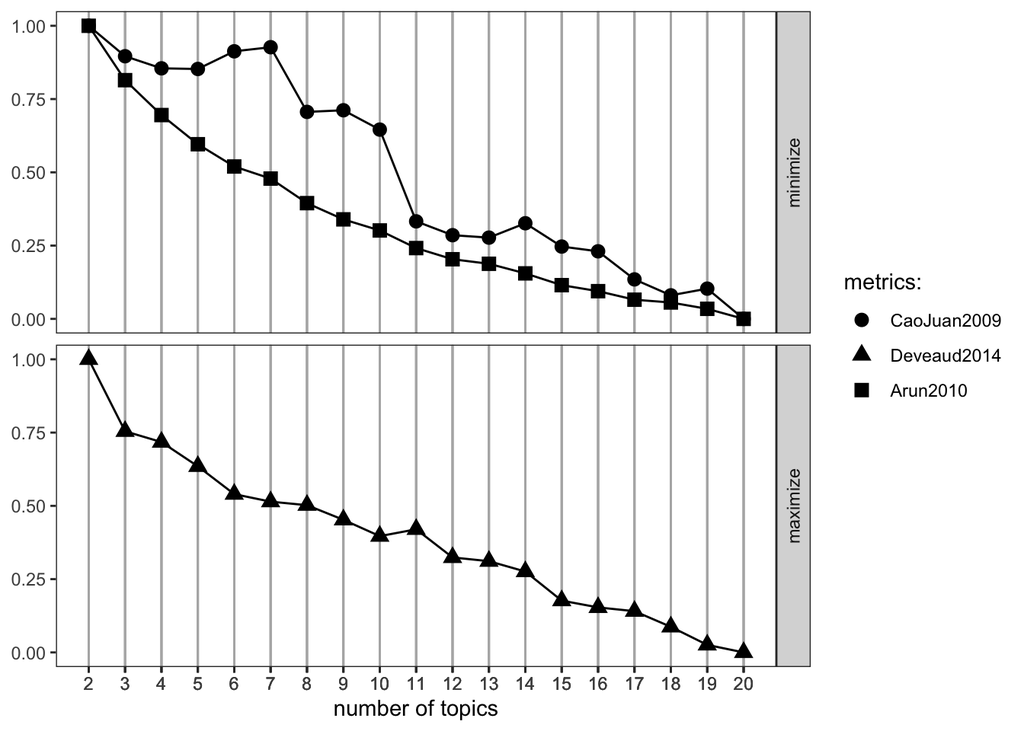

```r
FindTopicsNumber_plot(result)
```

To test out the very best value of K, I’ll try models with k = 19, k = 20, and another with a much lower value of k = 5 just to see since sometimes it feels like the words assigned to LDA models even when they are optimized don’t make a lot of intuitive sense.

```r
#first model with k = 5
k <- 5

topicModel_k5 <- LDA(dfm,
                     k,
                     method="Gibbs",
                     control=list(iter = 500, verbose = 25))
```

```
## K = 5; V = 3432; M = 105
## Sampling 500 iterations!
## Iteration 25 ...
## Iteration 50 ...
## Iteration 75 ...
## Iteration 100 ...
## Iteration 125 ...
## Iteration 150 ...
## Iteration 175 ...
## Iteration 200 ...
## Iteration 225 ...
## Iteration 250 ...
## Iteration 275 ...
## Iteration 300 ...
## Iteration 325 ...
## Iteration 350 ...
## Iteration 375 ...
## Iteration 400 ...
## Iteration 425 ...
## Iteration 450 ...
## Iteration 475 ...
## Iteration 500 ...
## Gibbs sampling completed!
```

```r
tmResult_k2 <- posterior(topicModel_k5)

#show top ten terms from each of the two topics
terms(topicModel_k5, 10)
```

```
##       Topic 1         Topic 2      Topic 3      Topic 4      Topic 5
##  [1,] "salmon"        "whales"     "lolita"     "$"          "said"
##  [2,] "species"       "orca"       "years"      "million"    "whales"
##  [3,] "fisheries"     "southern"   "orca"       "recovery"   "salmon"
##  [4,] "marine"        "said"       "whale"      "washington" "southern"
##  [5,] "endangered"    "noise"      "wild"       "federal"    "residents"
##  [6,] "will"          "will"       "seaquarium" "will"       "chinook"
##  [7,] "state"         "resident"   "return"     "protect"    "fish"
##  [8,] "environmental" "endangered" "pacific"    "act"        "population"
##  [9,] "fish"          "killer"     "family"     "program"    "also"
## [10,] "washington"    "whale"      "one"        "noaa"       "food"
```

```r
#model with k = 19
k <- 19

topicModel_k19 <- LDA(dfm,
                     k,
                     method="Gibbs",
                     control=list(iter = 500, verbose = 25))
```

```
## K = 19; V = 3432; M = 105
## Sampling 500 iterations!
## Iteration 25 ...
## Iteration 50 ...
## Iteration 75 ...
## Iteration 100 ...
## Iteration 125 ...
## Iteration 150 ...
## Iteration 175 ...
## Iteration 200 ...
## Iteration 225 ...
## Iteration 250 ...
## Iteration 275 ...
## Iteration 300 ...
## Iteration 325 ...
## Iteration 350 ...
## Iteration 375 ...
## Iteration 400 ...
## Iteration 425 ...
## Iteration 450 ...
## Iteration 475 ...
## Iteration 500 ...
## Gibbs sampling completed!
```

```r
tmResult_k19 <- posterior(topicModel_k19)

#show top ten terms from each of the two topics
terms(topicModel_k19, 10)
```

```
##       Topic 1      Topic 2      Topic 3      Topic 4         Topic 5
##  [1,] "endangered" "salmon"     "chinook"    "release"       "$"
##  [2,] "whales"     "fish"       "salmon"     "navy"          "million"
##  [3,] "killer"     "said"       "southern"   "environmental" "salmon"
##  [4,] "species"    "whales"     "fish"       "clean"         "washington"
##  [5,] "population" "state"      "food"       "state"         "state"
##  [6,] "said"       "killer"     "residents"  "toxic"         "murray"
##  [7,] "marine"     "also"       "even"       "inlet"         "program"
##  [8,] "federal"    "hatchery"   "whales"     "continue"      "will"
##  [9,] "protection" "production" "scientists" "water"         "national"
## [10,] "will"       "number"     "also"       "released"      "funding"
##       Topic 6    Topic 7     Topic 8      Topic 9         Topic 10
##  [1,] "seattle"  "including" "lolita"     "marine"        "whales"
##  [2,] "island"   "marine"    "orca"       "washington"    "said"
##  [3,] "time"     "noaa"      "seaquarium" "aquaculture"   "whale"
```

[output cut: 29 more lines]

```r
##save the results to proceed with 19 as best value
tmResult <- posterior(topicModel_k19)
terms(topicModel_k19, 10)
```

```
##       Topic 1      Topic 2      Topic 3      Topic 4         Topic 5
##  [1,] "endangered" "salmon"     "chinook"    "release"       "$"
##  [2,] "whales"     "fish"       "salmon"     "navy"          "million"
##  [3,] "killer"     "said"       "southern"   "environmental" "salmon"
##  [4,] "species"    "whales"     "fish"       "clean"         "washington"
##  [5,] "population" "state"      "food"       "state"         "state"
##  [6,] "said"       "killer"     "residents"  "toxic"         "murray"
##  [7,] "marine"     "also"       "even"       "inlet"         "program"
##  [8,] "federal"    "hatchery"   "whales"     "continue"      "will"
##  [9,] "protection" "production" "scientists" "water"         "national"
## [10,] "will"       "number"     "also"       "released"      "funding"
##       Topic 6    Topic 7     Topic 8      Topic 9         Topic 10
##  [1,] "seattle"  "including" "lolita"     "marine"        "whales"
##  [2,] "island"   "marine"    "orca"       "washington"    "said"
##  [3,] "time"     "noaa"      "seaquarium" "aquaculture"   "whale"
```

[output cut: 29 more lines]

```r
theta <- tmResult$topics
beta <- tmResult$terms
vocab <- (colnames(beta))
```

```r
#model with k = 20
k <- 20

topicModel_k20 <- LDA(dfm,
                     k,
                     method="Gibbs",
                     control=list(iter = 500, verbose = 25))
```

```
## K = 20; V = 3432; M = 105
## Sampling 500 iterations!
## Iteration 25 ...
## Iteration 50 ...
## Iteration 75 ...
## Iteration 100 ...
## Iteration 125 ...
## Iteration 150 ...
## Iteration 175 ...
## Iteration 200 ...
## Iteration 225 ...
## Iteration 250 ...
## Iteration 275 ...
## Iteration 300 ...
## Iteration 325 ...
## Iteration 350 ...
## Iteration 375 ...
## Iteration 400 ...
## Iteration 425 ...
## Iteration 450 ...
## Iteration 475 ...
## Iteration 500 ...
## Gibbs sampling completed!
```

```r
tmResult_k20 <- posterior(topicModel_k20)

#show top ten terms from each of the two topics
terms(topicModel_k20, 10)
```

```
##       Topic 1      Topic 2    Topic 3     Topic 4     Topic 5
##  [1,] "$"          "will"     "chinook"   "whale"     "species"
##  [2,] "million"    "orca"     "fish"      "return"    "marine"
##  [3,] "will"       "can"      "salmon"    "keiko"     "aquaculture"
##  [4,] "habitat"    "island"   "southern"  "toki"      "washington"
##  [5,] "washington" "us"       "even"      "lolita"    "endangered"
##  [6,] "salmon"     "oct"      "sea"       "tank"      "noaa"
##  [7,] "funding"    "year"     "river"     "sanctuary" "science"
##  [8,] "murray"     "festival" "whales"    "said"      "food"
##  [9,] "state"      "just"     "residents" "family"    "environmental"
## [10,] "program"    "event"    "food"      "killer"    "impact"
##       Topic 6      Topic 7      Topic 8      Topic 9      Topic 10
##  [1,] "lolita"     "salmon"     "endangered" "noise"      "lolita"
##  [2,] "years"      "said"       "killer"     "whales"     "wild"
##  [3,] "seaquarium" "whales"     "species"    "quiet"      "years"
```

[output cut: 29 more lines]

The topis seem to have a lot of overlap, perhaps because my search terms to begin with were so narrow - perhaps a corpus that covers a wider range of topics to begin with would fair better?

Looking at the terms in each topic, I would pick 19 as the single best value of k.

## Step 4

4. Plot the top terms in each topic and the distribution of topics across a sample of the documents (constrained by what looks good in the plot).

```r
orca_topics <- tidy(topicModel_k19, matrix = "beta")

top_terms <-orca_topics %>%
  group_by(topic) %>%
  top_n(7, beta) %>%
  ungroup() %>%
  arrange(topic, -beta)

top_terms
```

```
## # A tibble: 140 × 3
##    topic term         beta
##    <int> <chr>       <dbl>
##  1     1 endangered 0.0374
##  2     1 whales     0.0255
##  3     1 killer     0.0250
##  4     1 species    0.0210
##  5     1 population 0.0193
##  6     1 said       0.0159
##  7     1 marine     0.0159
##  8     2 salmon     0.0301
##  9     2 fish       0.0227
## 10     2 said       0.0167
## # … with 130 more rows
```

```r
topic_words <- terms(topicModel_k19, 3) #take  words from each topic to names

topic_names <- apply(topic_words, 2, paste, collapse = " ")
```

[figure not shown]

```r
top_terms %>%
  mutate(term = reorder_within(term, beta, topic, sep = "")) %>%
  ggplot(aes(term, beta, fill = factor(topic))) +
  geom_col(show.legend = FALSE) +
  facet_wrap(~ topic, scales = "free_y") +
  scale_x_reordered()+
  coord_flip() +
  labs(
    title = "Top six terms in each topic"
  )
```

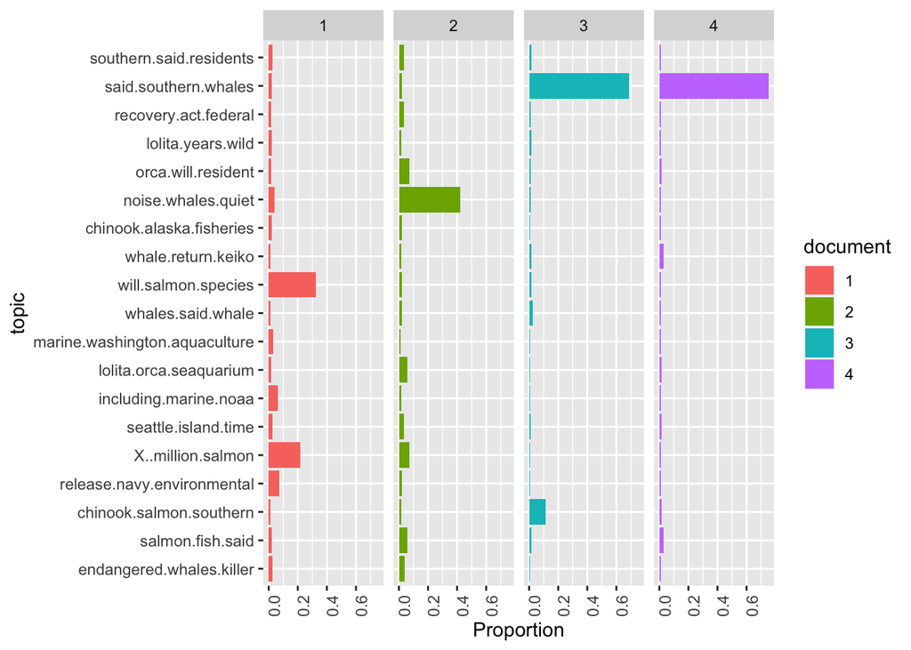

```r
example_ids <- c(1:4) #id for just a subset of first 4 documents (gets hard to read with more)

n <- length(example_ids)

# get topic proportions form example documents
topicProportions <- theta[example_ids,]
colnames(topicProportions) <- topic_names

#create df of doc id, topic name, and proportion
vizDF <- melt(cbind(data.frame(topicProportions), document = factor(1:n)),
              variable.name = "topic",
              id.vars = "document")

ggplot(
  data = vizDF,
  aes(x = topic,
      y = value,
      fill = document
      )
) +
  geom_bar(stat = "identity") +
  labs(
    y = "Proportion"
  ) +
  theme(axis.text.x = element_text(angle = 90, hjust = 1)) +
  coord_flip() +
  facet_wrap(~ document, ncol = n)
```

```r
## could continue to plot for next few documents, but instead might be more effective to look at interactive visualization
```

```r
svd_tsne <- function(x) tsne(svd(x)$u)
json <- createJSON(
  phi = tmResult$terms,
  theta = tmResult$topics,
  doc.length = rowSums(dfm),
  vocab = colnames(dfm),
  term.frequency = colSums(dfm),
  mds.method = svd_tsne,
  plot.opts = list(xlab="", ylab="")
)
```

```
## sigma summary: Min. : 33554432 |1st Qu. : 33554432 |Median : 33554432 |Mean : 33554432 |3rd Qu. : 33554432 |Max. : 33554432 |
```

```
## Epoch: Iteration #100 error is: 21.2320069999516
```

```
## Epoch: Iteration #200 error is: 0.689890966902924
```

```
## Epoch: Iteration #300 error is: 0.511244597026634
```

```
## Epoch: Iteration #400 error is: 0.42717555208735
```

```
## Epoch: Iteration #500 error is: 0.412401350920993
```

```
## Epoch: Iteration #600 error is: 0.409740237826254
```

```
## Epoch: Iteration #700 error is: 0.406761241711096
```

```
## Epoch: Iteration #800 error is: 0.402499558345738
```

```
## Epoch: Iteration #900 error is: 0.401481991398196
```

```
## Epoch: Iteration #1000 error is: 0.400954685804668
```

```r
serVis(json)
```

## Step 5

5. Take a stab at interpreting the resulting topics. What are the key themes discussed in the articles in your data base?

```r
print(topic_names)
```

```
##                         Topic 1                         Topic 2
##      "endangered whales killer"              "salmon fish said"
##                         Topic 3                         Topic 4
##       "chinook salmon southern"    "release navy environmental"
##                         Topic 5                         Topic 6
##              "$ million salmon"           "seattle island time"
##                         Topic 7                         Topic 8
##         "including marine noaa"        "lolita orca seaquarium"
##                         Topic 9                        Topic 10
## "marine washington aquaculture"             "whales said whale"
##                        Topic 11                        Topic 12
##           "will salmon species"            "whale return keiko"
##                        Topic 13                        Topic 14
##      "chinook alaska fisheries"            "noise whales quiet"
##                        Topic 15                        Topic 16
##            "orca will resident"             "lolita years wild"
##                        Topic 17                        Topic 18
##          "recovery act federal"          "said southern whales"
##                        Topic 19
##       "southern said residents"
```

Because I identified 19 topics (identified above with the top three terms in each) - there is a lot of overlap. I actually found the sentiment analysis (and just looking at the indiviudal word frequencies) a bit more intuitive and helpful than the topic analysis.

Some general themes that came from these topics are:

- Funding and policy efforts ($, million, will, recovery, federal, act)
- Issues with noise pollution and the navy interfering with the Southern Resident orcas (navy, noise, quiet)
- Issues with the orca’s feed stocks and fisheries (salmon, chinook, alaska, fish, aquaculture etc.)
- Issues with captive orcas and their re-release (Keiko, Lolita, seaquarium, wild)
- Conservation and research (NOAA, health, species, endangered, habitat)
- General info about the southern resident orca population (pod J, orca, southern)

Looking at the term frequency within each topic makes it easier to understand, but there is a lot of overlap. It’s also interesting that the topics shift each time without setting a seed - which makes me think the topic delineation isn’t necessarily strong enough for the method of initial randomization to always identify the same pattern.